# Analítica de datos aplicada a estudios sobre desarrollo

Introducción a las técnicas multivariantes no supervisadas

[Giovany Babativa, PhD](http://jgbabativam.rbind.io/)

## Proceso de analítica

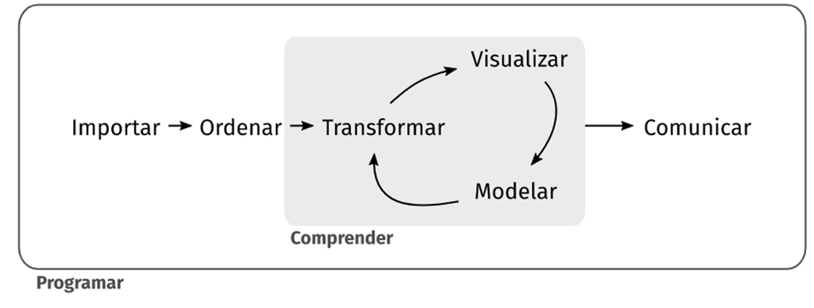

[Wickham, H. y otros (2023)](https://r4ds.hadley.nz/)

# MÉTODOS MULTIVARIANTES

## Modelos de analítica

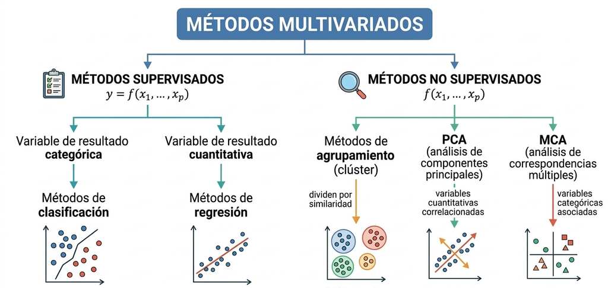

# ANÁLISIS DE CONGLOMERADOS

## ¿Qué es el análisis de agrupaciones (clúster)?

Conjunto de técnicas para agrupar objetos con base en la similitud que tienen en un vector de variables $\mathbf{x}' = (x_1, \ldots, x_p)$, **sin conocer de antemano** a qué grupo pertenece cada uno.

Un buen agrupamiento cumple dos condiciones simultáneas:

1. **Homogeneidad interna**: los objetos dentro de una misma agrupación (clúster) son lo más similares posible.
2. **Heterogeneidad externa**: las agrupaciones (clústeres) se diferencian claramente entre sí.

> A diferencia de la clasificación supervisada, aquí no existe una variable “respuesta” que indique el grupo verdadero: el algoritmo lo construye a partir de la estructura de los datos.

## Aplicaciones típicas

- **Segmentación de mercado**: agrupar clientes según hábitos de consumo para diseñar estrategias diferenciadas.
- **Tipologías sociales**: perfiles de ciudadanos según percepciones, actitudes o comportamientos (encuestas).
- **Caracterización territorial**: agrupar países, departamentos o municipios según indicadores socioeconómicos.
- **Reducción de complejidad**: resumir cientos de observaciones en unos pocos perfiles interpretables.
- **Insumo para otras técnicas**: crear una variable de grupo que luego se use en análisis descriptivo o predictivo.

## Tipos de análisis de agrupaciones (clúster)

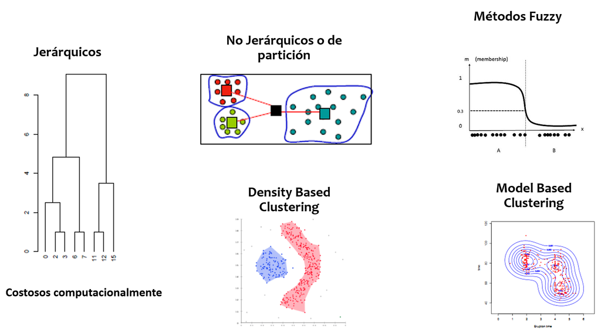

En este curso nos concentramos en los dos enfoques clásicos: **jerárquicos** y **de partición (no jerárquicos)**, y en su combinación mediante **HCPC**.

## Jerárquicos vs. no jerárquicos

**Jerárquicos**

Construyen un árbol (dendrograma) agrupando sucesivamente los elementos o grupos más próximos, sin fijar de antemano el número de agrupaciones (clústeres).

*Costosos computacionalmente para $n$ grande.*

**No jerárquicos (partición)**

Dividen el conjunto de objetos en un número **prefijado** $k$ de grupos, optimizando algún criterio (p. ej. minimizar la varianza intra-agrupación (intra-clúster)).

*Requieren definir $k$ antes de correr el algoritmo.*

## Etapas de un análisis de agrupaciones (clúster)

1. Definir claramente los **objetivos** del análisis.
2. Seleccionar las **variables** relevantes (evitar redundancia).
3. **Estandarizar** las variables para evitar el efecto de la escala.
4. Elegir una **medida de distancia** o disimilaridad.
5. Elegir el **algoritmo** de agrupación.
6. Obtener la **agrupación** y decidir el número de agrupaciones (clústeres).
7. **Validar** e interpretar los resultados.

## Estandarización

Cuando las variables tienen escalas distintas, las de mayor varianza dominan el cálculo de distancias. Se estandariza cada variable como:

$$z_{ij} = \frac{x_{ij} - \bar{x}_j}{s_j}, \qquad j = 1, \ldots, p$$

**Important**

Esto es indispensable quando las variables se miden en unidades diferentes (p. ej. ingresos en pesos y años de educación).

## Medidas de distancia

**Distancia euclídea** (la más usada con variables cuantitativas estandarizadas):

$$d_{ij} = \sqrt{\sum_{k=1}^p (x_{ik} - x_{jk})^2}$$

Otras alternativas según el tipo de variable:

- **Manhattan**: $d_{ij} = \sum_{k=1}^p |x_{ik} - x_{jk}|$ — más robusta a atípicos.
- **Distancia $\chi^2$**: para tablas de frecuencias (la misma del ACS/ACM).
- Existen además otras medidas (p. ej. **Gower**, para mezclas de variables cuantitativas y cualitativas) que no se profundizan en este capítulo.

> Cuando las variables activas provienen de un ACP o un ACM, ya se trabaja sobre coordenadas factoriales, ortogonales y en la misma escala: allí la distancia euclídea es la elección natural.

# Métodos no jerárquicos

## Algoritmo de las $K$-medias

Forgy (1965)

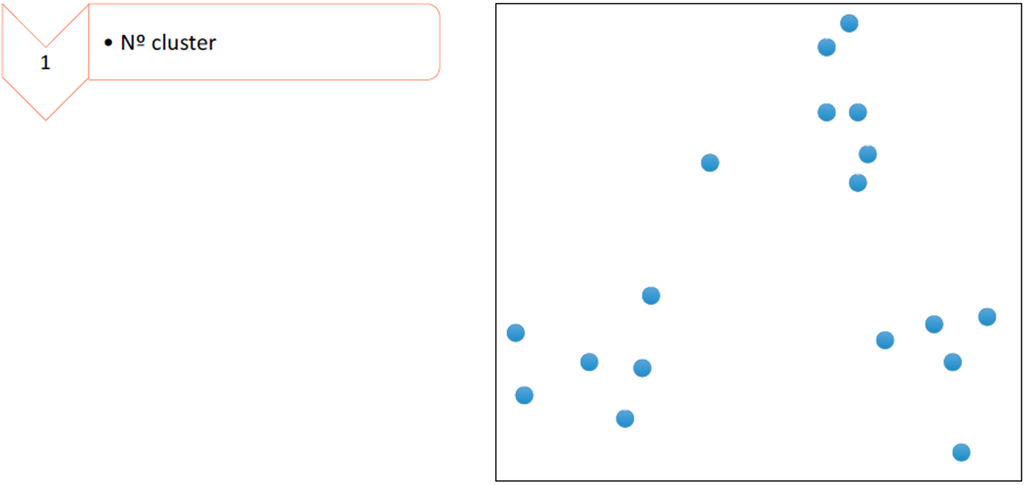

## Algoritmo de las $K$-medias

Forgy (1965)

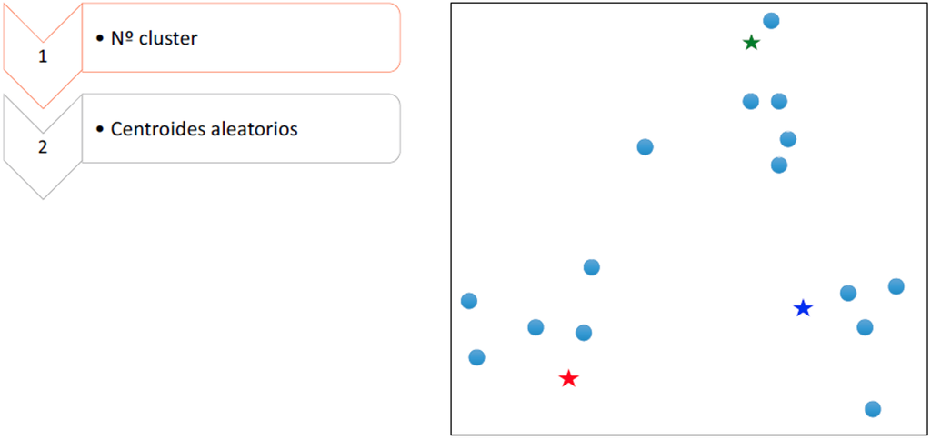

## Algoritmo de las $K$-medias

Forgy (1965)

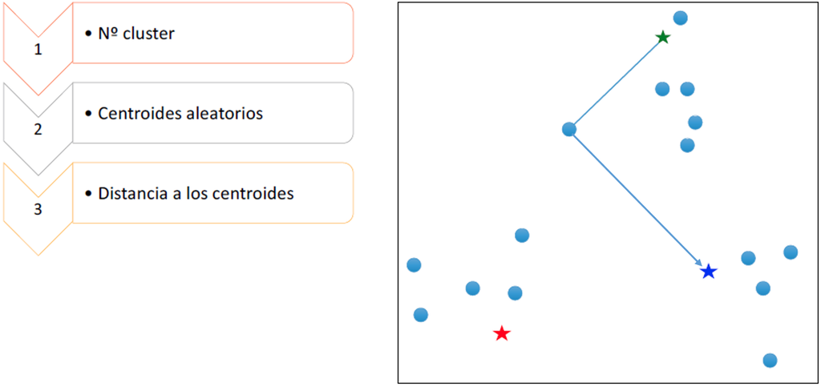

## Algoritmo de las $K$-medias

Forgy (1965)

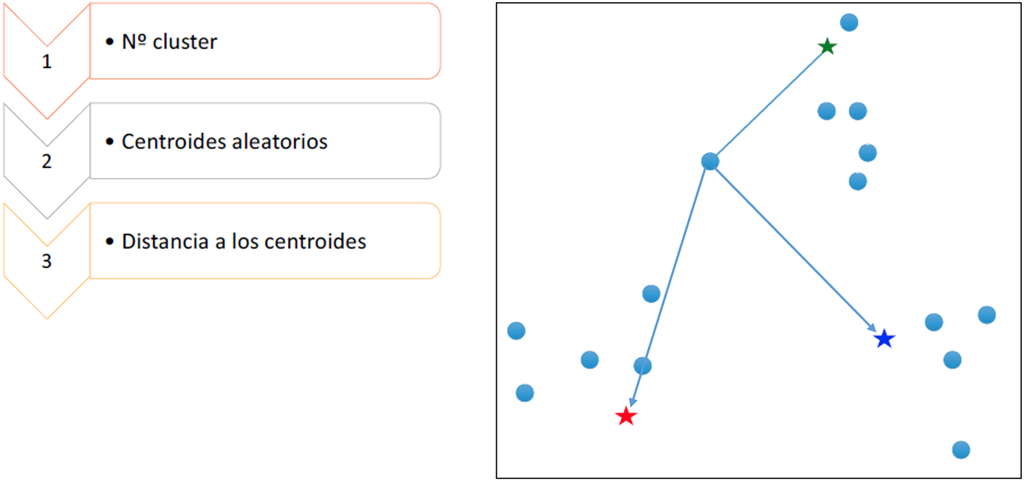

## Algoritmo de las $K$-medias

Forgy (1965)

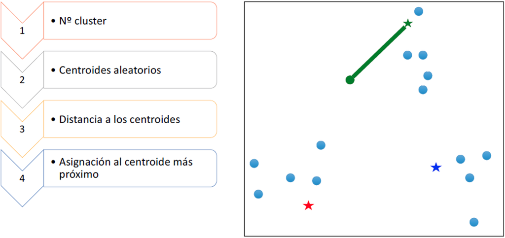

## Algoritmo de las $K$-medias

Forgy (1965)

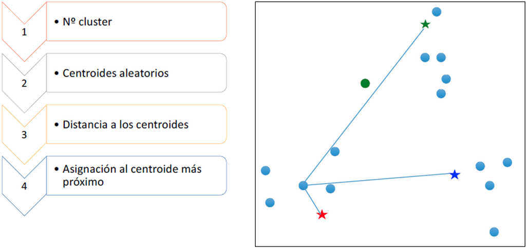

## Algoritmo de las $K$-medias

Forgy (1965)

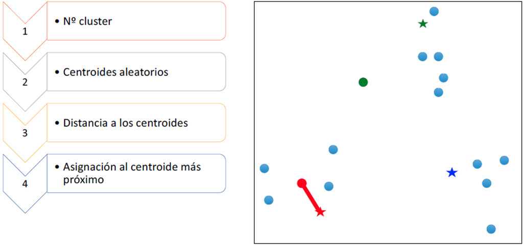

## Algoritmo de las $K$-medias

Forgy (1965)

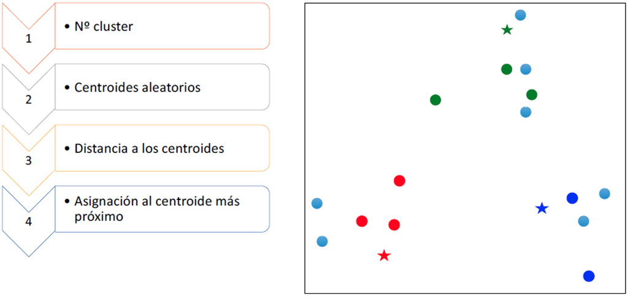

## Algoritmo de las $K$-medias

Forgy (1965)

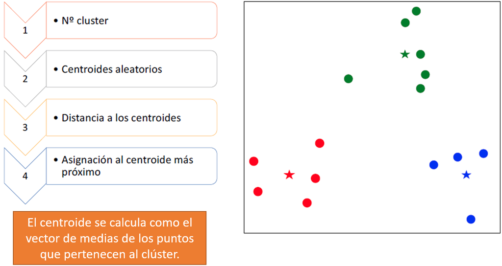

## Comparación de algoritmos

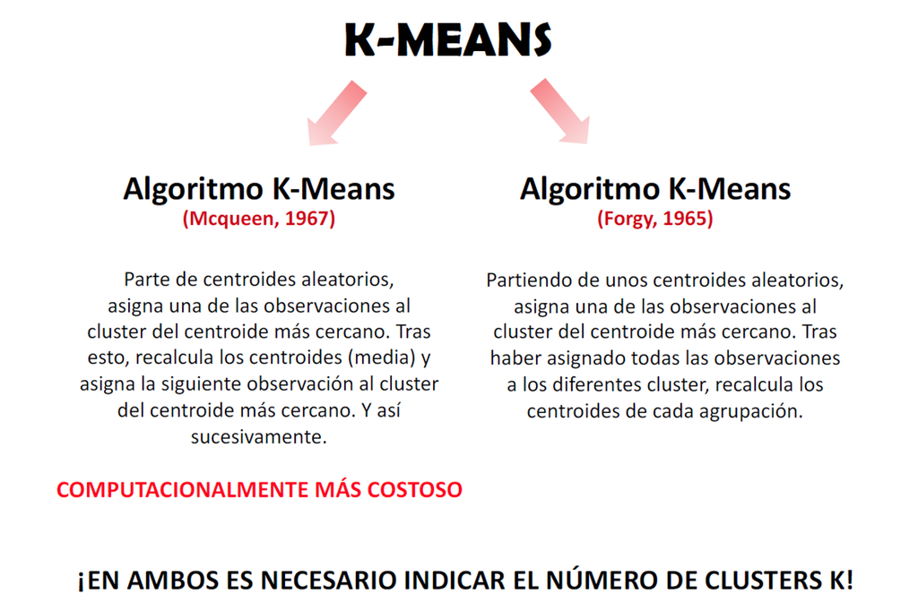

## Simulación

Ingrese a la siguiente página [Naftali](https://www.naftaliharris.com/blog/visualizing-k-means-clustering/)

- Seleccione los centros aleatoriamente y use una distribución uniforme, normal y alguna otra. Haga $k=3$ y realice la simulación del clúster.
- Seleccione los centros manualmente y use una distribución uniforme, normal y alguna otra. Haga $k=3$ y realice la simulación del clúster.

## Algoritmos alternativos

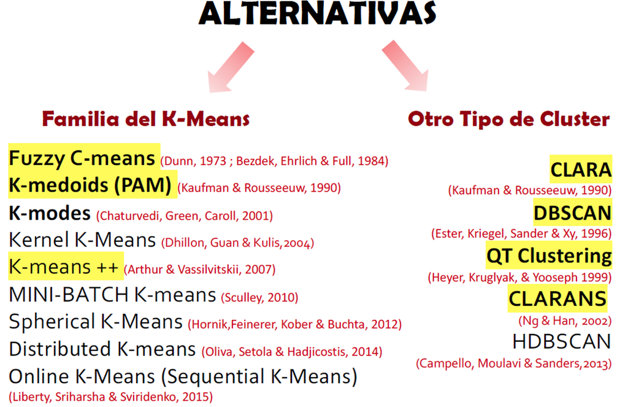

## Simulación DBSCAN

Ingrese a la siguiente página [Naftali](https://www.naftaliharris.com/blog/visualizing-dbscan-clustering/)

- Simule un proceso de DBSCAN

# Métodos jerárquicos

## Algoritmo para los métodos de aglomeración

1. Comenzar con tantas clases como elementos o individuos se tenga. Las distancias entre clases son las distancias entre elementos originales.
2. Seleccionar los dos elementos más próximos en la matriz de distancias y formar con ellos un grupo.
3. Sustituir los dos elementos utilizados en (2) para definir el grupo en (2), por un nuevo elemento que la represente.
4. Volver a (2) y repetir (2) y (3) hasta que tengamos todos los elementos queden agrupados en un solo grupo.

## Geometría del Análisis Clúster

Considere los siguientes datos artificiales:

```r
datos <- data.frame(
  Individuo = c("A", "B", "C", "D", "E", "F"),
  gastos = c(5, 6, 15, 16, 25, 30),
  educa = c(5, 6, 14, 15, 20, 19)
)
print(datos)
```

```
  Individuo gastos educa
1         A      5     5
2         B      6     6
3         C     15    14
4         D     16    15
5         E     25    20
6         F     30    19
```

## Geometría del Análisis Clúster

Considere los siguientes datos artificiales:

```r
library(tidyverse)

ggplot(datos, aes(x = gastos, y = educa, label = Individuo)) +
  geom_point(size = 3, color = "steelblue") +
  geom_text(vjust = -1) +
  labs(x = "Gastos", y = "Años de Educación") +
  theme_bw()
```

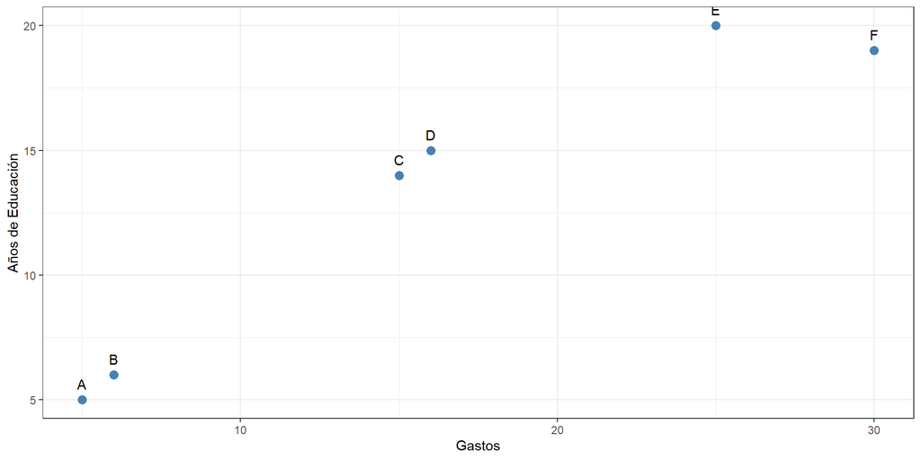

## Pasos para el análisis

1. Definir claramente los objetivos
2. Seleccionar las variables
3. Estandarizar las variables
4. Medidas de distancia
5. Algoritmo
6. Agrupación
7. Validación

## Estandarizar

$$z_{ij} = \frac{x_{ij} - \bar{x}_j}{s_j}$$

```r
(datos_z <- datos |>
            mutate(gastoz = (gastos - mean(gastos))/sd(gastos),
                   educaz = (educa - mean(educa))/sd(educa)))
```

```
  Individuo gastos educa      gastoz     educaz
1         A      5     5 -1.11797173 -1.2822130
2         B      6     6 -1.01785486 -1.1252073
3         C     15    14 -0.11680302  0.1308381
4         D     16    15 -0.01668615  0.2878437
5         E     25    20  0.88436570  1.0728721
6         F     30    19  1.38495005  0.9158664
```

## Distancias

Distancia Euclídea:
$$d_{ij}=\sqrt{\sum_{k=1}^p(x_{ik}-x_{jk})^2}$$

```r
(distancias <- dist(datos_z[, c("gastoz", "educaz")]))
```

```
          1         2         3         4         5
2 0.1862100
3 1.7317771 1.5458151
4 1.9177873 1.7317771 0.1862100
5 3.0912426 2.9068877 1.3746879 1.1950581
6 3.3310915 3.1526899 1.6945595 1.5359025 0.5246289
```

## Algoritmo de aglomeración jerárquico

```r
hc_single <- hclust(distancias, method = "single")

plot(hc_single, labels = datos$Individuo, main = "Clúster jerárquico (Vecino más cercano)",
     sub = "", xlab = "", ylab = "Distancia")
rect.hclust(hc_single, k = 2, border = "red")
```

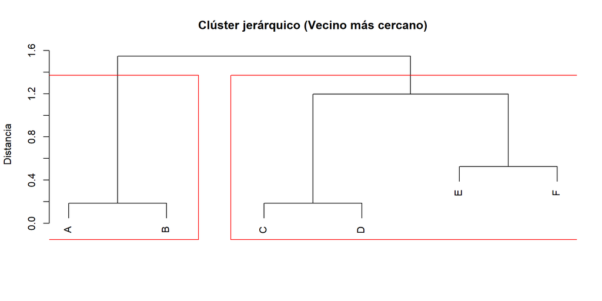

## Algoritmo de k-medias

```r
set.seed(123)
km <- kmeans(datos_z[, c("gastoz", "educaz")], centers = 2)

datos_z$cluster <- as.factor(km$cluster)

centros <- as.data.frame(km$centers)
colnames(centros) <- c("gastoz", "educaz")
ggplot(datos_z, aes(x = gastoz, y = educaz, color = cluster, label = Individuo)) +
  geom_point(size = 4) +
  geom_text(vjust = -1) +
  geom_point(data = centros, aes(x = gastoz, y = educaz),
             color = "black", size = 5, shape = 8,
             inherit.aes = FALSE) +
  theme_bw()
```

[output not shown]

# EJEMPLOS

## Consumo de proteinas

Considere el conjunto de datos del taller sobre el consumo de proteínas en algunos países de Europa. Realice un análisis clúster a partir de:

1. Un algoritmo de $K$-medias para agrupar a los países en 3 grupos.
2. Un algoritmo de aglomeración jerárquica. Defina el número de grupos apropiado.

## Paso 1: Importar el conjunto de datos

```r
options(scipen = 999)
library(pacman)

p_load(tidyverse, janitor, haven,
       FactoMineR, factoextra, cluster)

url <- "https://github.com/jgbabativam/AnaDatos/raw/main/datos/PaisesProteinas.sav"

datos <- read_sav(url)
```

## Paso 2: Preparar los datos

En el algoritmo de las $K$-medias es indispensable que las variables de análisis sea de tipo cuantitativo. Además, las variables son estandarizadas para evitar el efecto de la escala, de manera que:

$$z_{i} =\frac{x_i - \bar{x}_i}{s_i}, i=1,\ldots, p$$

```r
datos <- datos |>
         column_to_rownames(var = "Pais") |>
         scale()
```

# Algoritmo de $K$-medias

## Paso 3: Aplicar el algoritmo

```r
set.seed(26052013)

res <- kmeans(datos, centers = 3)

datos.clus <- data.frame(datos, cluster = res$cluster)
```

## Paso 4: Visualización

```r
fviz_cluster(res, data = datos,
             palette = c("#2E9FDF", "#00AFBB", "#E7B800"),
             geom = "point",
             ellipse.type = "convex",
             main = "Cluster de países",
             ggtheme = theme_bw()
             )
```

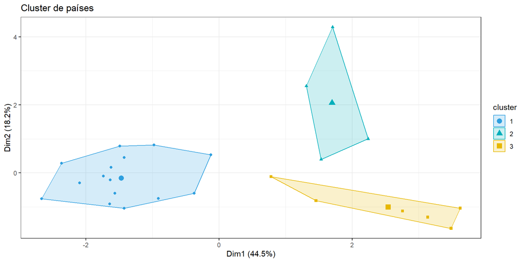

## Paso 5: Interpretación

```r
datos.clus |>
  group_by(cluster) |>
  summarise(across(where(is.numeric), ~mean(., na.rm=T)))
```

```
# A tibble: 3 × 10
  cluster CarneRoja CarneBlanca Huevsos  Leche Pescado Cereales Féculas
    <int>     <dbl>       <dbl>   <dbl>  <dbl>   <dbl>    <dbl>   <dbl>
1       1     0.452       0.506   0.576  0.584   0.118   -0.610   0.353
2       2    -0.509      -1.11   -0.412 -0.832   0.982    0.130  -0.184
3       3    -0.790      -0.527  -1.17  -0.905  -0.950    1.44   -0.760
# ℹ 2 more variables: Frutossecos <dbl>, Frutosyvegetales <dbl>
```

# Algoritmo de jerárquico de Ward

## La idea del HCPC

`HCPC()` (*Hierarchical Clustering on Principal Components*) combina lo mejor de los dos mundos vistos hasta ahora, en tres etapas:

1. **Reducción de dimensión**: se parte de las coordenadas factoriales de un ACP, ACM o ACS (en vez de las variables originales).
2. **Clasificación jerárquica** (Ward) sobre esas coordenadas, para construir el dendrograma y sugerir el número de agrupaciones (clústeres).
3. **Consolidación** de la partición con un algoritmo de $K$-medias, partiendo de los centros de gravedad obtenidos en el paso jerárquico, utilizando como valor de $K$ el número de agrupaciones (clústeres) que acaba de generar la clasificación jerárquica en el paso anterior.

## ¿Por qué trabajar sobre componentes?

- Las coordenadas factoriales son **ortogonales**: se elimina la redundancia (correlación) entre variables originales.
- Al retener solo los primeros ejes se **filtra ruido** y se reduce el costo computacional.
- Permite unificar el flujo de trabajo: el **mismo objeto** (`PCA()`, `MCA()` o `CA()`) alimenta tanto el mapa factorial como la clasificación.
- `HCPC()` produce, además del dendrograma, una **caracterización automática** de cada agrupación (clúster): qué variables (o modalidades) lo tipifican.

## Paso 3: Aplicar PCA

```r
res.pca <- PCA(datos, graph = F)
fviz_pca_var(res.pca,
             col.var="contrib",
             gradient.cols = c("#00AFBB", "#E7B800", "#FC4E07"),
             repel = TRUE)
```

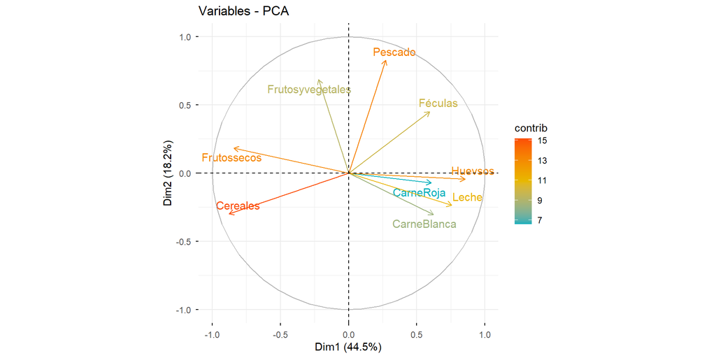

## Paso 3: Aplicar PCA

```r
fviz_pca_ind(res.pca, col.ind = "cos2",
             gradient.cols = c("#00AFBB", "#E7B800", "#FC4E07"),
             repel = TRUE)
```

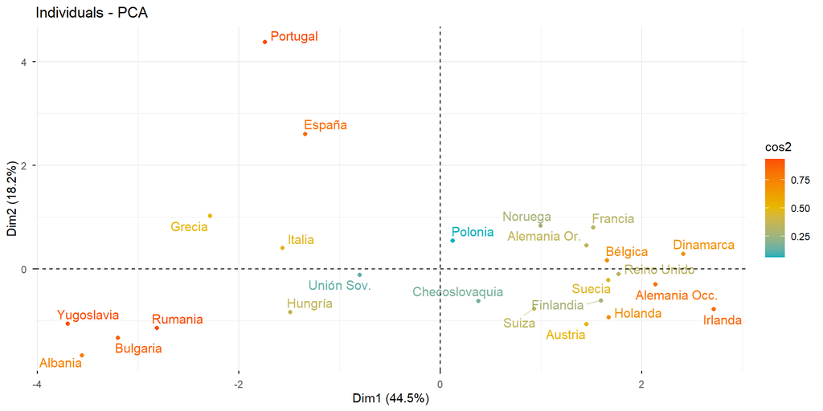

## Paso 4: Aplicar clúster jerárquico

Defina primero el número de clúster que se debería usar basado en el criterio de los índices de nivel o inercia iterclases.

```r
res.clus <- HCPC(res.pca)
```

[output not shown]

```r
res.clus <- HCPC(res.pca, nb.clust = 5, graph = FALSE)
```

## Paso 5: Visualización del dendrograma

```r
fviz_dend(res.clus,
          cex = 0.7,
          palette = "jco",
          rect = TRUE, rect_fill = TRUE,
          horiz = TRUE,
          rect_border = "jco",
          labels_track_height = 0.8,
          main = "Cluster de paises"
          )
```

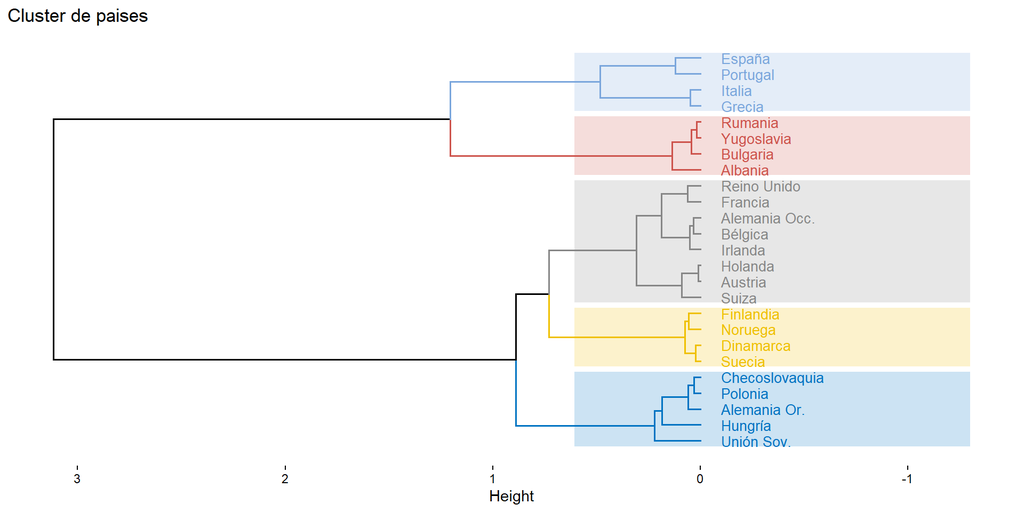

## Paso 5: Visualización del plano de países

```r
fviz_cluster(res.clus,
             repel = TRUE,
             show.clust.cent = TRUE,
             palette = "jco",
             ggtheme = theme_minimal(),
             main = "Clúster de países"
             )
```

```r
# Puede usar el comando `res.clus$desc.var$quanti` para analizar la caracterización de cada clúster.
```

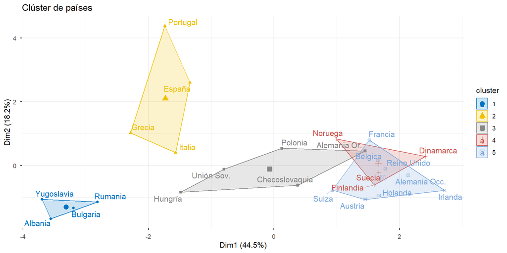

## Ejemplo Electoral

Realice un análisis de correspondencias y posteriormente un análisis clúster para concluir sobre el perfil de los candidatos.

## Paso 1: Importar el conjunto de datos

```r
library(pacman)

p_load(tidyverse, janitor, haven, readxl,
       FactoMineR, factoextra, cluster)

url <- "https://github.com/jgbabativam/AnaDatos/raw/main/datos/caPolitico.sav"

datos <- read_sav(url)
```

## Paso 2: Preparar los datos

```r
datos <- datos |>
         column_to_rownames(var = "atributo")
```

## Paso 3: Análisis de correspondencias

```r
res.ac <- CA(t(datos), graph = F)

fviz_ca_biplot(res.ac,
               col.row="blue",
               col.col = "red",
               repel = TRUE) +
       theme_minimal()
```

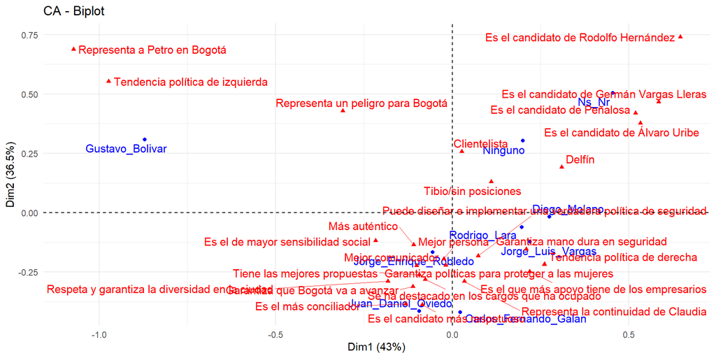

## Paso 4: Clasificación de candidatos

Defina primero el número de clúster que se debería usar basado en el criterio de los índices de nivel o inercia iterclases.

```r
res.clus <- HCPC(res.ac)
```

[output not shown]

```r
res.clus <- HCPC(res.ac, nb.clust = 5, graph = FALSE)
```

## Paso 5: Visualización del dendrograma

```r
fviz_dend(res.clus,
          cex = 0.7,  palette = "jco",
          rect = TRUE, rect_fill = TRUE, horiz = TRUE,
          rect_border = "jco", labels_track_height = 0.8,
          main = "Cluster de candidatos"
          )
```

```r
#Puede usar el comando `res.clus$desc.var` y `res.clus$desc.ind` para analizar la caracterización de cada clúster.
```

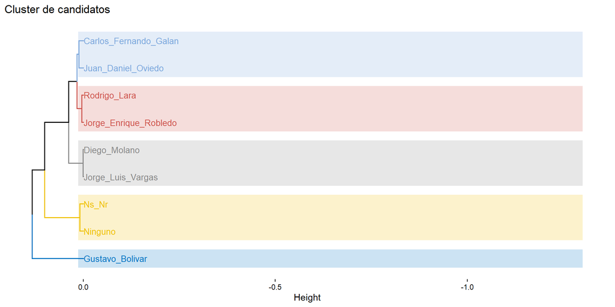

# Ejercicios

1. Con los datos de Violencia Sexual, realice una caracterización de las mujeres y las formas de violencia.
2. Use los datos electorales para realizar una caracterización usando otras variables categóricas.
3. Use los datos del estudio DASS para realizar una caracterización de los docentes.

# GRACIAS!

# Referencias

- Husson, F., Lê, S., & Pagès, J. (2017). Exploratory multivariate analysis by example using R. CRC press.
- Hair, J. F., Black, W. C., Babin, B. J., Anderson, R. E., & Tatham, R. L. (2006). Multivariate data analysis 6th Edition. https://doi.org/10.1201/9780367409913
- Aldás Manzano, J., & Uriel Jiménez, E. (2017). Análisis multivariante aplicado con R. Ediciones Paraninfo, SA.